# Introduction to SC19019

SC19019

2020-01-02

## Overview

**SC19019** is a simple R package developed to compare the performance of R and R++ (implemented through the R package *Rcpp*) for the ‘Statistical Computing’ course. Two functions are considered, namely, *fr* (find the bets k for kNN) and *fc* (add). For fr function, R version is produced. Namely *StatCompR*. For fc function, C++ version is produced. Namely *StatCompC*.

The source R code for *fr* is as follows:

```r
fr=function(x){
  z=rnorm(100)
  d=sort(abs(z-x))
  y=numeric(100)
  for(k in 1:100){
    y[k]=k/2/100/d[k]
  }
  dis=abs(y-dnorm(x))
  re=which.min(dis)
  return(re)
}
```

Input x. Generate 100 standard normal numbers. Caculate the density estimate in x by knn method for k from 1 to 100. Find the best k for x.

The source R code for *fc* is as follows:

```r
library(Rcpp) # Attach R package "Rcpp"
# Define function "fc"
cppFunction('int fc(int x, int y, int z) {
int sum = x + y + z;
return sum;
}')
```

Input three integer numbers. Return their sum.

## Question

Use knitr to produce at least 3 examples(texts,figures,tables).

## Answer

Use Rmarkdown to produce html.Use knitr to produce 3 examples in the html.Each example includes texts,figures and tables.

## Example 1

Comparing frequency distribution and probability distribution by sampling size.

1.Generate 100 random numbers with normal distribution.

```r
a=rnorm(100,mean=0,sd=1)
summary(a)
```

```
##     Min.  1st Qu.   Median     Mean  3rd Qu.     Max.
## -2.45046 -0.53641  0.02064  0.07398  0.67934  2.15912
```

Draw frequency histogram and density curve.

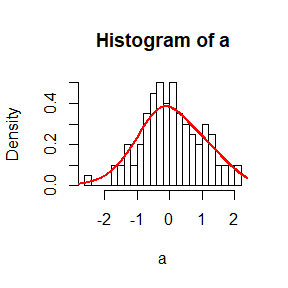

```r
hist(a, freq = F, breaks = 30)
lines(density(a, bw=.5), col="red", lwd=2)
```

2.Generate 1000 random numbers with normal distribution.

```r
b=rnorm(1000,mean=0,sd=1)
summary(b)
```

```
##      Min.   1st Qu.    Median      Mean   3rd Qu.      Max.
## -3.078267 -0.667952 -0.004578 -0.007290  0.676328  3.401081
```

Draw frequency histogram and density curve.

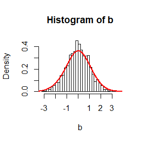

```r
hist(b, freq = F, breaks = 30)
lines(density(b, bw=.5), col="red", lwd=2)
```

The result shows intuitively that the larger the sample, the closer the frequency distribution is to the overall probability distribution.

## Example 2

Research the mean of tne sum of two normal random variables with the same variance and different mean by sample.

```r
x1=rnorm(1000,1,1)
x2=rnorm(1000,3,1)
x3=x1+x2
mean(x3)
```

```
## [1] 3.995736
```

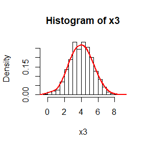

```r
hist(x3, freq = F, breaks = 30)
lines(density(x3, bw=.5), col="red", lwd=2)
```

```r
x4=cbind(x1,x2,x3)
library(knitr)
kable(head(x4),format="markdown")
```

| x1 | x2 | x3 |
| --- | --- | --- |
| 0.2154131 | 2.637727 | 2.853140 |
| 0.4142170 | 2.130266 | 2.544484 |
| 2.9113729 | 3.704466 | 6.615839 |
| 1.2772061 | 4.155219 | 5.432425 |
| 0.8562370 | 2.124555 | 2.980792 |
| 1.9822640 | 2.527970 | 4.510234 |

The result shows The mean of the sum is the sum of the mean.

## Example 3

Using plot function.

```r
library(knitr)
y1=runif(100)
y2=rnorm(100)
y3=rexp(100)
y4=cbind(y1,y2,y3,y1^2,y2^2,y3^2)
kable(head(y4),format="markdown")
```

| y1 | y2 | y3 |  |  |  |
| --- | --- | --- | --- | --- | --- |
| 0.8928612 | -0.3108292 | 0.5432959 | 0.7972012 | 0.0966148 | 0.2951705 |
| 0.0994767 | 1.3634029 | 3.7695096 | 0.0098956 | 1.8588676 | 14.2092023 |
| 0.6766745 | 1.7976910 | 1.1705629 | 0.4578884 | 3.2316929 | 1.3702176 |
| 0.5459220 | -1.0243618 | 0.0648656 | 0.2980308 | 1.0493171 | 0.0042076 |
| 0.1604883 | -0.1386703 | 0.5442756 | 0.0257565 | 0.0192294 | 0.2962359 |
| 0.9614549 | -0.3616605 | 0.1162613 | 0.9243955 | 0.1307983 | 0.0135167 |

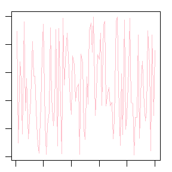

```r
par(mar=c(1,1,1,1))
plot(y1,type="l",col="pink")
```

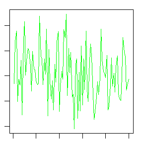

```r
plot(y2,type="l",col="green")
```

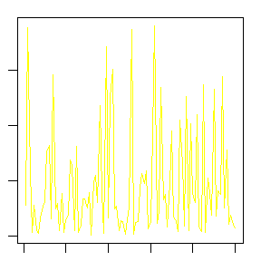

```r
plot(y3,type="l",col="yellow")
```

## Question1

The Rayleigh density [156, Ch. 18] is
$$f(x)=\frac{x}{\sigma^{2}} e^{-x^{2} /\left(2 \sigma^{2}\right)}, \quad x \geq 0, \sigma>0$$
Develop an algorithm to generate random samples from a Rayleigh(σ) distri- bution. Generate Rayleigh(σ) samples for several choices of σ > 0 and check that the mode of the generated samples is close to the theoretical mode σ (check the histogram).

## Answer1

Use inverse transform method.First of all, integrate pdf f(x) to get cdf F(x).
$$\begin{aligned} F(x) &=\int_{0}^{x} f(u) d u \\ &=\int_{0}^{x} \frac{u}{\sigma^{2}} e^{-u^{2} /(2 \sigma^{2})} d u \\ &=-\left.e^{-u^{2} /(2 \sigma^{2})}\right|_{0} ^{x} \\ &=1-e^{-x^{2}}\left(2 \sigma^{2}\right) \end{aligned}$$

Next,Find the inverse function of F.
$$F^{-1}(x)=\sqrt{-2 \sigma^{2} \ln (1-x)}$$
Then,Generate uniform distributed random numbers u.$X=F^{-1}(u) \sim F(x)$ are what we need.

```r
n=10000                        #size of samples
f_sigma=function(sigma){
  u=runif(n)
  x=sqrt(-2*sigma^2*log(1-u))
  x
}
```

f_sigma is a function to generate random samples from a Rayleigh(σ) distribution.

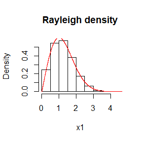

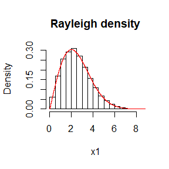

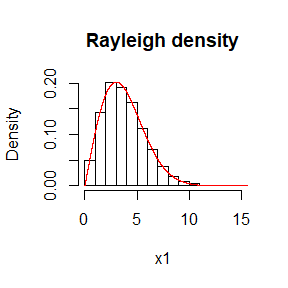

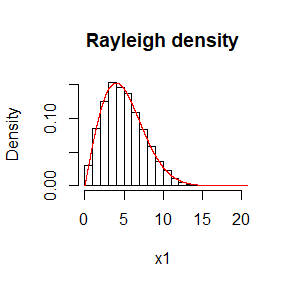

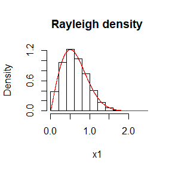

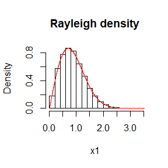

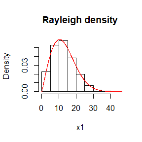

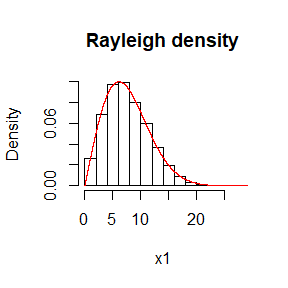

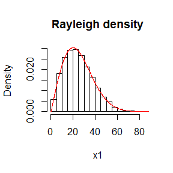

```r
par=(mar=c(1,1,1,1,1,1,1,1,1))
sigma=c(1,2,3,4,0.5,0.7,10.3,6.1,20)
for(i in 1:9){
x1=f_sigma(sigma[i])
hist(x1,prob=TRUE,main="Rayleigh density")
y <- seq(0, 100, .001)
lines(y, y/sigma[i]^2*exp(-y^2/(2*sigma[i]^2)),col="red")
}
```

I generate Rayleigh(σ) samples for 9 choices of σ > 0 and the results tell us the mode of the generated samples is close to the theoretical mode σ.

## Question2

Generate a random sample of size 1000 from a normal location mixture. The components of the mixture have N(0,1) and N(3,1) distributions with mixing probabilities p1 and p2 = 1 − p1 . Graph the histogram of the sample with density superimposed, for p1 = 0.75. Repeat with different values for p1 and observe whether the empirical distribution of the mixture appears to be bimodal. Make a conjecture about the values of p1 that produce bimodal mixtures.

## Answer2

First,we definate a function mixture_p1 to generate a random sample of size 1000 from a normal location mixture. The components of the mixture have N(0,1) and N(3,1) distributions with mixing probabilities p1 and p2 = 1 − p1 .

```r
n=1000
mixture_p1=function(p1){
r=sample(c(0,1),size=n,replace=TRUE,prob=c(1-p1,p1))
#p1 for N(0,1),p2=1-p1 for N(3,1)
x1=rnorm(n,0,1)
x2=rnorm(n,3,1)
z=r*x1+(1-r)*x2
hist(z,,breaks=50,prob=TRUE)
lines(density(z),col="red")
}
```

Next, graph the histogram of the sample with density superimposed, for p1 = 0.75.

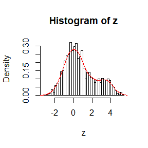

```r
mixture_p1(0.75)
```

Then,repeat with different values for p1 and observe whether the empirical distribution of the mixture appears to be bimodal.

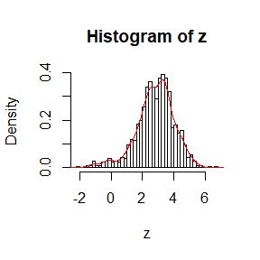

```r
mixture_p1(0.05)
```

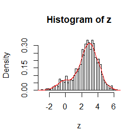

```r
mixture_p1(0.15)
```

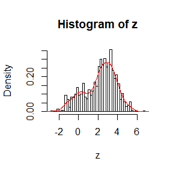

```r
mixture_p1(0.25)
```

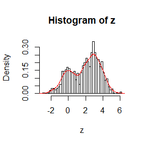

```r
mixture_p1(0.35)
```

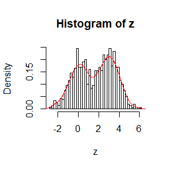

```r
mixture_p1(0.45)
```

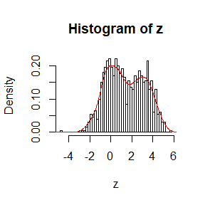

```r
mixture_p1(0.55)
```

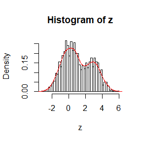

```r
mixture_p1(0.65)
```

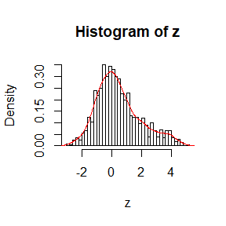

```r
mixture_p1(0.85)
```

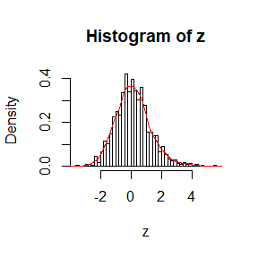

```r
mixture_p1(0.95)
```

Based on these images,we have reason to guess that the closer P is to 0.5, the more obvious the bimodal distribution is.Repeat more.

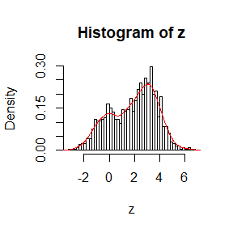

```r
mixture_p1(0.37)
```

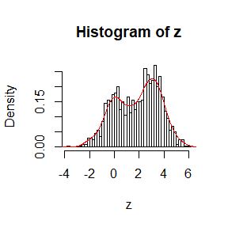

```r
mixture_p1(0.4)
```

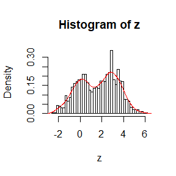

```r
mixture_p1(0.43)
```

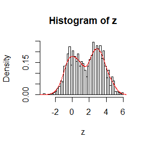

```r
mixture_p1(0.47)
```

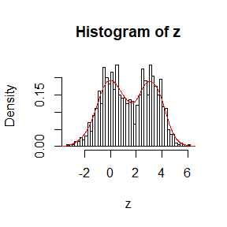

```r
mixture_p1(0.5)
```

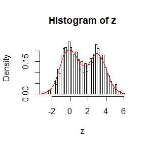

```r
mixture_p1(0.53)
```

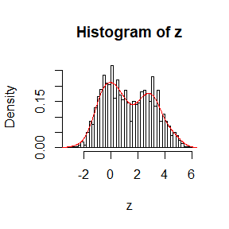

```r
mixture_p1(0.57)
```

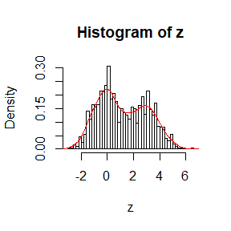

```r
mixture_p1(0.6)
```

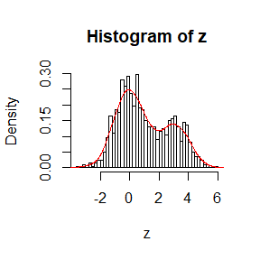

```r
mixture_p1(0.63)
```

This result supports our conjecture.The closer P is to 0.5, the more obvious the bimodal distribution is.

## Question3

Write a function to generate a random sample from a Wd (Σ,n) (Wishart) distribution for n > d + 1 ≥ 1, based on Bartlett’s decomposition.

## Answer3

Based on Bartlett’s decomposition,a variate X~Wd(Σ,n) can be write as X=LAA’L’.L is the cholesky factor of Σ.
$$A=\left(\begin{array}{cccc}{c_{1}} & {0} & {\cdots} & {0} \\ {n_{21}} & {c_{2}} & {} & {\vdots} \\ {n_{31}} & {n_{32}} & {\ddots} & {\vdots} \\ {\vdots} & {\vdots} & {} & {\vdots} \\{n_{d1}} & {n_{d2}} & {\cdots} & {c_{d}}\end{array}\right) , c_{i}^{2} \sim \chi_{n+1-i}^{2}, n_{i j} \sim N(0,1)$$

Now,let’s write the function which can generate a random sample from a Wd(Σ,n).

```r
wishart=function(sigma,n,d){
  if(n<d+2||d<0) print("please input integers n>d+1 and d>=0")
  else{
    A=matrix(numeric(d^2),d,d)
    for(i in 1:d){
      A[i,i]=sqrt(rchisq(1,n+1-i))
      for(j in 1:d){
        if(j<i) A[i,j]=rnorm(1)
        else if(j>i) A[i,j]=0
        else A[i,j]=A[i,i]
      }
    }#definate matrix A
    L=t(chol(sigma))  #Compute the Choleski factorization of sigma.
    X=L%*%A%*%t(A)%*%t(L)   #based on Bartlett's decompsition
  }
  X
}
```

Try this function with specific parameters.

```r
sigma=matrix(c(5,1,1,3),2,2)
d=2
n=4
wishart(sigma,n,d)
```

```
##           [,1]     [,2]
## [1,] 15.369791 2.623759
## [2,]  2.623759 5.674252
```

The result X is the random sample genereted by the function we write and x~Wd(Σ,n).

## Question1

Compute a Monte Carlo estimate of
$$\int_{0}^{\pi / 3} \sin t d t$$
and compare your estimate with the exact value of the integral.

## Answer1

$$\int_{0}^{\pi / 3} \sin t d t=E\left(\frac{\pi}{3} \sin t\right), t\sim U\left(0, \frac{\pi}{3}\right)$$

```r
set.seed(1)
m=1e4
x=runif(m,min=0,max=pi/3)
y=mean(pi/3*sin(x))
print(c(y,-cos(pi/3)+cos(0)))
```

```
## [1] 0.4997336 0.5000000
```

The result shows my estimate is close to the exact value of the integral.

## Question2

Use Monte Carlo integration with antithetic variables to estimate
$$\int_{0}^{1} \frac{e^{-x}}{1+x^{2}} d x$$
and find the approximate reduction in variance as a percentage of the variance without variance reduction.

## Answer2

$$\begin{array}{l}{\theta=\int_{0}^{1} \frac{e^{-x}}{1+x^{2}} d x=E\left(\frac{e^{-x}}{1+x^{2}}\right), x \sim U(0,1)} \\ {\hat{\theta}=\frac{1}{m} \sum_{i=1}^{m / 2}\left(\frac{e^{-x_{i}}}{1+x_{i}^{2}}+\frac{e^{-\left(1-x_{i}\right)}}{1+\left(1-x_{i}\right)^{2}}\right), x_{i} \sim U(0,1)}\end{array}$$

```r
set.seed(12)
m=1e4
x=runif(m)
x1=x[1:m/2]
u1=exp(-x1)/(1+x1^2)
u2=exp(-(1-x1))/(1+(1-x1)^2)
y1=(u1+u2)/2
theta.hat=mean(y1)#with variance reduction
y2=exp(-x)/(1+x^2)
theta.hat2=mean(y2) #without variance reduction
c(theta.hat,theta.hat2,var(y1),var(y2),1-var(y1)/var(y2))
```

```
## [1] 0.524207129 0.523415081 0.001117801 0.060587333 0.981550581
```

The approximate reduction in variance as a percentage of the variance without variance reduction is 98.155%.

## Question3

Obtain the stratified importance sampling estimate in Example 5.13 and com- pare it with the result of Example 5.10.

## Answer3

Divide the interval (0,1) into five subintervals, $(\alpha_{j-1},\alpha_j)$, $\alpha_j=F^{-1}(j/5)$ ,j = 1,…,5.F is the cdf of f3 in Example 5.13.
$$F=\frac{1-e^{-x}}{1-e^{-1}},0<x<1.$$
Then on the jth subinterval variables are generated from the density
$$\frac{5e^{-x}}{1-e^{-1}},\alpha_{j-1}<x<\alpha_j.$$

$$\begin{array}{l}{\int_{0}^{1} \frac{e^{-x}}{1-e^{-1}} d x=\frac{1}{5} \sum_{j=1}^{5} \int_{\alpha_{j-1}}^{\alpha_j} \frac{5 e^{-x}}{1-e^{-1}} d x} \\ {g(x)=\frac{5 e^{-x}}{1-e^{-1}}} \\ {\int_{\alpha_{j-1}}^{\alpha_j} g(x)dx=\int_{0}^{1} \frac{g(x)}{f(x)} I\left(\alpha_{j-1}<x<\alpha_j\right) f(x) d x} \\ {\quad=E \frac{g(X)}{f(X)} I\left(\alpha_{j-1}<X<\alpha_j\right), X \sim f(x)}\end{array}$$

```r
sub=function(a,b){#write a function for every subinterval to obtain importance sampling
m <- 10000
theta.hat <- se <- numeric(5)
g <- function(x) {
5*exp(-x - log(1+x^2))
}
u <- runif(m/5) #f3, inverse transform method
x <- - log(1 - u * (1 - exp(-1)))
fg <- g(x) / (exp(-x) / (1 - exp(-1)))*(x>a)*(x<b)
theta.hat <- mean(fg)
return(theta.hat)
}
```

```r
set.seed(54321)
alpha=c(0,0,0,0,0,1)#(0,1)分成五个子区间，第i个子区间的端点是(j-1)/5分位数和j/5分位数
for(j in 1:5){
  f=function(x)(1-exp(-x))/(1-exp(-1))-(j-1)/5
alpha[j]=uniroot(f,c(0,1))$root
}#求分位数
est=c(rep(0,50))
T=numeric(0)
for(i in 1:50){
for(j in 1:5)
  T[j]=sub(alpha[j],alpha[j+1])
  est[i]=mean(T)
}
c(mean(est),sd(est))
```

```
## [1] 0.52278639 0.01034668
```

The stratified importance sampling estimate in Example 5.13 is 0.52278639,sd id smaller than Example 5.10.

## Question1

Suppose a 95% symmetric t-interval is applied to estimate a mean, but the sample data are non-normal. Then the probability that the confidence interval covers the mean is not necessarilyequal to 0.95. Use a Monte Carlo experiment to estimate the coverage probability of the t-interval for random samples of $\chi^2(2)$ data with sample size n = 20. Compare your t-interval results with the simulation results in Example 6.4. (The t-interval should be more robust to departures from normality than the interval for variance.)

## Answer1

### basic idea:

Generate random samples of Chi-Squared distribution with 2 degrees.Estimating mean value with t interval.Use a Monte Carlo experiment to estimate the coverage probability of the t-interval.Then compare the t-interval results with the simulation results in Example 6.4.

```r
set.seed(11)
alpha=0.05
n=20
x=rchisq(n,2)
s=sd(x)
l1=mean(x)-s/sqrt(n)*qt(1-alpha/2,n-1)
l2=mean(x)+s/sqrt(n)*qt(1-alpha/2,n-1)
c(l1,l2)
```

```
## [1] 0.7014312 2.3798327
```

```r
set.seed(12)
m=1000
l1=l2=k=numeric(m)
for(i in 1:m){
x=rchisq(n,2)
s=sd(x)
l1[i]=mean(x)-s/sqrt(n)*qt(1-alpha/2,n-1)#卡方分布期望等于自由度
l2[i]=mean(x)+s/sqrt(n)*qt(1-alpha/2,n-1)
k[i]=(l1[i]<=2)*(2<=l2[i])
}
mean(k)
```

```
## [1] 0.922
```

### conclusion

Through 1000 tests, the coverage probability is estimated to be 0.922.Compare the t-interval results with the simulation results in Example 6.4.The t-interval is smaller than the interval for variance.The t-interval is more robust to departures from normality than the interval for variance.

## Question2

Estimate the 0.025, 0.05, 0.95, and 0.975 quantiles of the skewness $\sqrt b_1$ under normality by a Monte Carlo experiment. Compute the standard error of the estimates from (2.14) using the normal approximation for the density (with exact variance formula). Compare the estimated quantiles with the quantiles of the large sample approximation $\sqrt b_1$≈ N(0,6/n).

## Answer2

### basic idea:

First,Sampling from Standard Normal Distribution,calculate skewness for each sample.Use the sample quantile as the estimation value. Second,use the normal approximation for the density (with exact variance formula) to Compute the standard error of the estimates.The normal approximation for the density is the density of N(0,6/n). Third,Compare the estimated quantiles with the quantiles of the large sample approximation $\sqrt b_1$≈ N(0,6/n).

Write a function g(x) to generate skewness of random sample.

```r
g=function(x){
  a=mean((x-mean(x))^3)
  b=(mean((x-mean(x))^2))^(3/2)
  return(a/b)
}
```

Obtain samples.

```r
set.seed(3)
m=10000
n=200
b=numeric(m)
for(i in 1:m){
  x=rnorm(n)
  b[i]=g(x)
}
```

Estimate the 0.025, 0.05, 0.95, and 0.975 quantiles.

```r
qb=numeric(4)
qb=quantile(b,probs=c(0.025,0.05,0.95,0.975))
qb
```

```
##       2.5%         5%        95%      97.5%
## -0.3285621 -0.2758854  0.2797988  0.3323775
```

Compute the standard error.

```r
varb=function(q){
  xq=qnorm(q,0,sqrt(6/n))
  return(q*(1-q)/n/dnorm(xq,0,sqrt(6*(n-2)/(n+1)/(n+3)))^2)
}
q=c(0.025,0.05,0.95,0.975)
varb1=numeric(4)
for(i in 1:4)
  varb1[i]=varb(q[i])
sqrt(varb1)
```

```
## [1] 0.03416744 0.02656640 0.02656640 0.03416744
```

Compare the estimated quantiles with the quantiles of the large sample approximation $\sqrt b_1$≈ N(0,6/n).

```r
qnorm(q,0,sqrt(6/n))
```

```
## [1] -0.3394757 -0.2848970  0.2848970  0.3394757
```

```r
qb
```

```
##       2.5%         5%        95%      97.5%
## -0.3285621 -0.2758854  0.2797988  0.3323775
```

### conclusion

The result shows that the estimated quantiles are close to the quantiles of the large sample approximation $\sqrt b_1$≈ N(0,6/n).

## Question1

Efron and Tibshirani discuss the scor (bootstrap)test score data on 88 students who took examinations in five subjects [84, Table 7.1], [188, Table 1.2.1].The first two tests (mechanics, vectors) were closed book and the last three tests (algebra, analysis, statistics) were open book. Each row of the data frame is a set of scores (x i1 ,…,x i5 ) for the i th student. Use a panel display to display the scatter plots for each pair of test scores. Compare the plot with the sample correlation matrix. Obtain bootstrap estimates of the standard errors for each of the following estimates: $\hat\rho_{12} = \hat\rho(mec, vec)$, $\hat\rho_{34} = \hat\rho(alg,ana)$, $\hat\rho_{35} = \hat\rho(alg, sta)$, $\hat\rho_{45} = \hat\rho(ana, sta)$.

## Answer1

### basic idea

First,obtain scor data, and display the scatter plots for each pair of test scores.

Scend,caculate the sample correlation matrix, and compare the plot with the sample correlation matrix.

Third,Obtain bootstrap estimates of the standard errors estimates.

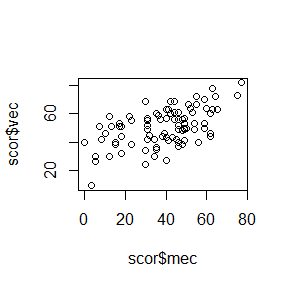

```r
library("bootstrap")
 plot(scor$mec,scor$vec)
```

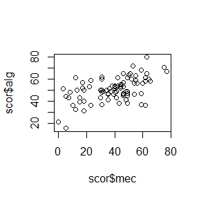

```r
 plot(scor$mec,scor$alg)
```

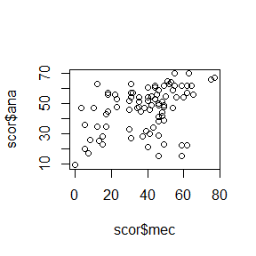

```r
 plot(scor$mec,scor$ana)
```

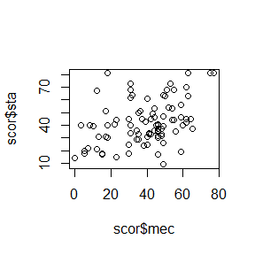

```r
 plot(scor$mec,scor$sta)
```

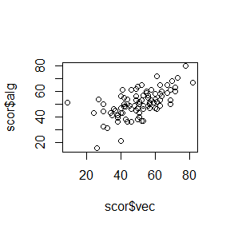

```r
 plot(scor$vec,scor$alg)
```

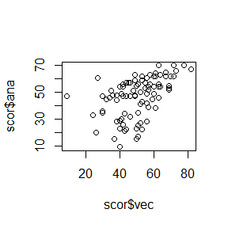

```r
 plot(scor$vec,scor$ana)
```

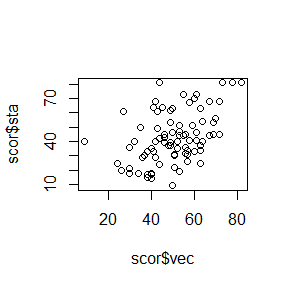

```r
 plot(scor$vec,scor$sta)
```

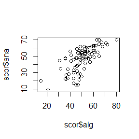

```r
 plot(scor$alg,scor$ana)
```

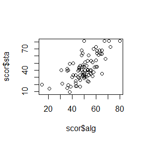

```r
 plot(scor$alg,scor$sta)
```

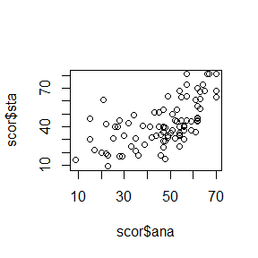

```r
 plot(scor$ana,scor$sta)
```

Above are scatter plots for each pair of test scores.Scatter plots can visually show correlation.If the data is more correlated, the scatter plot will be more concentrated. We can see the plots of vec&alg, ana&alg and sta&alg are more concentrated , and they show that vec&alg, sat&ana, ana&alg and sta&alg are more correlated.

```r
cor(scor)
```

```
##           mec       vec       alg       ana       sta
## mec 1.0000000 0.5534052 0.5467511 0.4093920 0.3890993
## vec 0.5534052 1.0000000 0.6096447 0.4850813 0.4364487
## alg 0.5467511 0.6096447 1.0000000 0.7108059 0.6647357
## ana 0.4093920 0.4850813 0.7108059 1.0000000 0.6071743
## sta 0.3890993 0.4364487 0.6647357 0.6071743 1.0000000
```

In the sample correlation matrix,the correlation coefficients of ana&alg, sta&alg, alg&vec and sta&ana are bigger than others.The bigger correlation coefficient shows more correlated.

### compare:

Scatter plots can visually show correlation.More concentrated means more correlated.Correlation matrix can accurately represent correlation.Bigger correlation coefficient means more correlated.Compare them,we can find the more concentrated scatter plots a pair data have, they will also have bigger correlation coefficient.The small correlation coefficient always with Scattered scatter plot.

```r
B=1e3
set.seed(123)
rho12=cor(scor$mec,scor$vec)
rho12star=rho34star=rho35star=rho45star=numeric(B)
for(b in 1:B){
  x1star=sample(1:nrow(scor),replace=TRUE)
  rho12star[b]=cor(scor$mec[x1star],scor$vec[x1star])
  rho34star[b]=cor(scor$alg[x1star],scor$ana[x1star])
  rho35star[b]=cor(scor$alg[x1star],scor$sta[x1star])
  rho45star[b]=cor(scor$ana[x1star],scor$sta[x1star])
}
se12.boot=sd(rho12star)
se34.boot=sd(rho34star)
se35.boot=sd(rho35star)
se45.boot=sd(rho45star)
print(c(se12.boot,se34.boot,se35.boot,se45.boot))
```

```
## [1] 0.07792347 0.04839544 0.06071384 0.06692171
```

### Conclusion:

Scatter plots can visually show correlation.More concentrated means more correlated.Correlation matrix can accurately represent correlation.Bigger correlation coefficient means more correlated.Compare them,we can find the more concentrated scatter plots a pair data have, they will also have bigger correlation coefficient.The small correlation coefficient always with Scattered scatter plot.

## Question2

Repeat Project 7.A for the sample skewness statistic. Compare the coverage rates for normal populations (skewness 0) and $\chi^2\left(5\right)$ distributions (positive skewness).

## Answer2

### basic idea

First,repeat Project 7.A for the sample skewness statistic for normal populations (skewness 0) and $\chi^2\left(5\right)$ distributions (positive skewness).Obtain a sample from normal distribution and $\chi^2\left(5\right)$ distribution.Use bootstrap method to estimate the CI(standard normal,basic and percent).

Scend,use MC method to caculate the coverage rates.

Third,compare the coverage rates for normal populations and $\chi^2\left(5\right)$ distributions.

Write a function to estimate bootstrap CI(standard normal,basic and percent):

```r
g=function(x){
  a=mean((x-mean(x))^3)
  b=(mean((x-mean(x))^2))^(3/2)
  return(a/b)
}
m=100
alpha=0.05
CI=function(sample1,sample2,dist){ #The parameter dist is for selecting distribution and CI
b1=b2=numeric(m)
for(j in 1:m){
  x1=sample(sample1,replace=TRUE)
  x2=sample(sample2,replace=TRUE)
  b1[j]=g(x1)
  b2[j]=g(x2)
}
se1=sd(b1)
se2=sd(b2)
thetahat1=g(sample1)
thetahat2=g(sample2)
if(dist==11){
  CI1_stand=c(thetahat1-qnorm(1-alpha/2)*se1,thetahat1-qnorm(alpha/2)*se1)
  return(CI1_stand)
}
else if(dist==12){
  CI2_stand=c(thetahat2-qnorm(1-alpha/2)*se2,thetahat2-qnorm(alpha/2)*se2)
  return(CI2_stand)
}
else if(dist==21){
  CI1_basic=c(2*thetahat1-quantile(b1,probs=1-alpha/2),2*thetahat1-quantile(b1,probs=alpha/2))
  return(CI1_basic)
}
else if(dist==22){
  CI2_basic=c(2*thetahat2-quantile(b2,probs=1-alpha/2),2*thetahat2-quantile(b2,probs=alpha/2))
  return(CI2_basic)
  }
else if(dist==31){
  CI1_perc=c(quantile(b1,probs=alpha/2),quantile(b1,probs=1-alpha/2))
  return(CI1_perc)
}
else if(dist==32){
  CI2_perc=c(quantile(b2,probs=alpha/2),quantile(b2,probs=1-alpha/2))
  return(CI2_perc)
}
else cat("Error,dist should be included in{11,12,21,22,31,32}!","\n")
}
```

Caculate the true skewness:

```r
theta1=0
f=function(x) ((x-5)/sqrt(2*5))^3*dchisq(x,5)
theta2=integrate(f,0,Inf)$value
theta2#the true skewness of chisq
```

```
## [1] 1.264911
```

The empirical coverage rates for the bootstrap CI caculated by MC method:

```r
set.seed(2333)
ita=1000 #times of MC
test1=test2=matrix(numeric(9),ncol=3)#test1 for normal,test2 for chisq
colnames(test1)=colnames(test2)=c("cover","left_miss","right_miss")
rownames(test1)=rownames(test2)=c("normal_CI","basic_CI","perc_CI")
test11=test12=test21=test22=test31=test32=testl11=testl12=testl21=testl22=testl31=testl32=testr11=testr12=testr21=testr22=testr31=testr32=numeric(ita)
for(i in 1:ita){
  s1=rnorm(20)
  s2=rchisq(20,5)
  test11[i]=(CI(s1,s2,11)[1]<=theta1)*(CI(s1,s2,11)[2]>=theta1)
  test12[i]=(CI(s1,s2,12)[1]<=theta2)*(CI(s1,s2,12)[2]>=theta2)
  test21[i]=(CI(s1,s2,21)[1]<=theta1)*(CI(s1,s2,21)[2]>=theta1)
  test22[i]=(CI(s1,s2,22)[1]<=theta2)*(CI(s1,s2,22)[2]>=theta2)
  test31[i]=(CI(s1,s2,31)[1]<=theta1)*(CI(s1,s2,31)[2]>=theta1)
  test32[i]=(CI(s1,s2,32)[1]<=theta2)*(CI(s1,s2,32)[2]>=theta2)
  testl11[i]=(CI(s1,s2,11)[1]>=theta1);testl12[i]=(CI(s1,s2,12)[1]>=theta2);
  testl21[i]=(CI(s1,s2,21)[1]>=theta1);testl22[i]=(CI(s1,s2,22)[1]>=theta2);
  testl31[i]=(CI(s1,s2,31)[1]>=theta1);testl32[i]=(CI(s1,s2,32)[1]>=theta2);
  testr11[i]=(CI(s1,s2,11)[2]<=theta1);testr12[i]=(CI(s1,s2,12)[2]<=theta2);
  testr21[i]=(CI(s1,s2,21)[2]<=theta1);testr22[i]=(CI(s1,s2,22)[2]<=theta2);
  testr31[i]=(CI(s1,s2,31)[2]<=theta1);testr32[i]=(CI(s1,s2,32)[2]<=theta2)
}
test1[1,1]=mean(test11);test1[1,2]=mean(testl11);test1[1,3]=mean(testr11);
test1[2,1]=mean(test21);test1[2,2]=mean(testl21);test1[2,3]=mean(testr21);
test1[3,1]=mean(test31);test1[3,2]=mean(testl31);test1[3,3]=mean(testr31);
test2[1,1]=mean(test12);test2[1,2]=mean(testl12);test2[1,3]=mean(testr12);
test2[2,1]=mean(test22);test2[2,2]=mean(testl22);test2[2,3]=mean(testr22);
test2[3,1]=mean(test32);test2[3,2]=mean(testl32);test2[3,3]=mean(testr32)
#For normal population:
test1
```

```
##           cover left_miss right_miss
## normal_CI 0.928     0.025      0.040
## basic_CI  0.856     0.061      0.081
## perc_CI   0.955     0.019      0.032
```

```r
#For $\chi^2\left(5\right)$ population:
test2
```

```
##           cover left_miss right_miss
## normal_CI 0.710     0.000      0.288
## basic_CI  0.667     0.045      0.281
## perc_CI   0.672     0.000      0.330
```

### Conclusion:

1.For normal populations

The coverage rates for the normal CI and the percentile CI are bigger than the basic CI.So the standard normal bootstrap CI and the percentile bootstrap CI are better than the basic bootstrap CI for normal populations.

In every CI estimating method,the proportion of times that the confidence intervals miss on the left is about equal to the porportion of times that the confidence intervals miss on the right.

#### Compare the coverage rates for normal populations and $\chi^2\left(5\right)$ distributions:

For each of normal CI,basic CI and percentile CI,the coverage rates for normal populations are bigger than $\chi^2\left(5\right)$ distributions.

## Question1

Estimate the power of the skewness test of normality against symmetric Beta(α,α) distributions and comment on the results. Are the results different for heavy-tailed symmetric alternatives such as t(ν)?

## Answer1

### Basic idea:

First,Estimate the power of the skewness test of normality against symmetric Beta(α,α) distributions and comment on the results. Second,Estimate the power of the skewness test of normality against t(ν) distributions and comment on the results. Third,compare them.

Write a function g(x) to generate skewness of random sample.

```r
g=function(x){
  a=mean((x-mean(x))^3)
  b=(mean((x-mean(x))^2))^(3/2)
  return(a/b)
}
```

Estimate the power of the skewness test of normality against symmetric Beta(α,α) distributions.

```r
f=function(alpha,a){
n=30
m=1000
cv <- qnorm(1-alpha/2, 0, sqrt(6*(n-2) / ((n+1)*(n+3))))
sktests <- numeric(m)
for (i in 1:m) { #for each replicate
  x=rbeta(n,a,a)
  sktests[i] <- as.integer(abs(g(x)) >= cv)
}
pwr <- mean(sktests)
return(pwr)
}
```

Calculate some results.

```r
set.seed(1)
a=seq(1,20,1)
Pwr=matrix(c(rep(0,60)),nrow=3)
alpha=c(0.05,0.07,0.1)
for(i in 1:3)
for(j in 1:20)
  Pwr[i,j]=f(alpha[i],a[j])
Pwr
```

```
##       [,1]  [,2]  [,3]  [,4]  [,5]  [,6]  [,7]  [,8]  [,9] [,10] [,11] [,12]
## [1,] 0.003 0.009 0.009 0.017 0.011 0.025 0.016 0.018 0.026 0.033 0.033 0.039
## [2,] 0.005 0.009 0.014 0.015 0.028 0.024 0.038 0.031 0.049 0.053 0.047 0.047
## [3,] 0.011 0.016 0.023 0.038 0.031 0.048 0.042 0.050 0.060 0.069 0.072 0.068
##      [,13] [,14] [,15] [,16] [,17] [,18] [,19] [,20]
## [1,] 0.032 0.022 0.029 0.038 0.039 0.036 0.049 0.045
## [2,] 0.048 0.047 0.063 0.065 0.043 0.059 0.042 0.056
## [3,] 0.077 0.072 0.086 0.082 0.075 0.075 0.090 0.073
```

Comment1:The power is too small.So the skewness test of normality is not suitable for symmetric Beta(α,α) distributions.

Estimate the power of the skewness test of normality against t(v) distributions.

```r
f2=function(alpha,v){
n=30
m=1000
cv <- qnorm(1-alpha/2, 0, sqrt(6*(n-2) / ((n+1)*(n+3))))
sktests <- numeric(m)
for (i in 1:m) { #for each replicate
  x=rt(n,v)
  sktests[i] <- as.integer(abs(g(x)) >= cv)
}
pwr <- mean(sktests)
return(pwr)
}
```

Calculate some results.

```r
set.seed(2)
v=seq(1,20,1)
Pwr2=matrix(c(rep(0,60)),nrow=3)
alpha=c(0.05,0.07,0.1)
for(i in 1:3)
for(j in 1:20)
  Pwr2[i,j]=f2(alpha[i],v[j])
Pwr2
```

```
##       [,1]  [,2]  [,3]  [,4]  [,5]  [,6]  [,7]  [,8]  [,9] [,10] [,11] [,12]
## [1,] 0.858 0.576 0.422 0.340 0.244 0.220 0.191 0.182 0.148 0.131 0.129 0.120
## [2,] 0.856 0.619 0.490 0.336 0.270 0.245 0.230 0.200 0.171 0.150 0.170 0.134
## [3,] 0.865 0.648 0.521 0.388 0.346 0.285 0.232 0.268 0.219 0.172 0.178 0.175
##      [,13] [,14] [,15] [,16] [,17] [,18] [,19] [,20]
## [1,] 0.109 0.114 0.104 0.109 0.087 0.107 0.093 0.091
## [2,] 0.146 0.139 0.128 0.140 0.109 0.111 0.129 0.122
## [3,] 0.184 0.175 0.182 0.141 0.156 0.155 0.145 0.123
```

Comment2:The results are different for heavy-tailed symmetric alternatives such as t(ν).The power of t(v) is larger.

## Conclusion

The skewness test of normality is suitable for t(v) distributions,but not suitable for Beta(α,α).

## Question2

Use Monte Carlo simulation to investigate whether the empirical Type I error rate of the t-test is approximately equal to the nominal significance level α, when the sampled population is non-normal. The t-test is robust to milddepartures from normality. Discuss the simulation results for the cases where the sampled population is (i)$\chi^2(1)$, (ii) Uniform(0,2), and (iii) Exponential(rate=1). In each case, test H0 : µ = µ0 vs H1 : µ != µ0 , where µ0 is the mean of $\chi^2(1)$, Uniform(0,2), and Exponential(1), respectively.

## Answer2

## Basic idea:

First,use Monte Carlo simulation to investigate whether the empirical Type I error rate of the t-test is approximately equal to the nominal significance level α, when the sampled population is $\chi^2(1)$. Second,use Monte Carlo simulation to investigate whether the empirical Type I error rate of the t-test is approximately equal to the nominal significance level α, when the sampled population is Uniform(0,2). Third,use Monte Carlo simulation to investigate whether the empirical Type I error rate of the t-test is approximately equal to the nominal significance level α, when the sampled population is Exponential(1). Each simulation was performed three times for three different alpha.

For $\chi^2(1)$.The mean is 1.

```r
set.seed(21)
alpha=0.025
m <- 10000
n=20
test1 <- numeric(m) #test decisions
for (j in 1:m) {
x1 <- rchisq(n,1)
s1=sd(x1)
#test decision is 1 (reject) or 0
l1=1-s1/sqrt(n)*qt(1-alpha/2,n-1)
l2=1+s1/sqrt(n)*qt(1-alpha/2,n-1)
test1[j] <- 1-(mean(x1) >=l1 )*(mean(x1) <=l2)
}
p.reject1 <- mean(test1) #proportion rejected
p.reject1
```

```
## [1] 0.0783
```

```r
set.seed(21)
alpha=0.05
m <- 10000
n=20
test1 <- numeric(m) #test decisions
for (j in 1:m) {
x1 <- rchisq(n,1)
s1=sd(x1)
#test decision is 1 (reject) or 0
l1=1-s1/sqrt(n)*qt(1-alpha/2,n-1)
l2=1+s1/sqrt(n)*qt(1-alpha/2,n-1)
test1[j] <- 1-(mean(x1) >=l1 )*(mean(x1) <=l2)
}
p.reject1 <- mean(test1) #proportion rejected
p.reject1
```

```
## [1] 0.1058
```

```r
set.seed(21)
alpha=0.1
m <- 10000
n=20
test1 <- numeric(m) #test decisions
for (j in 1:m) {
x1 <- rchisq(n,1)
s1=sd(x1)
#test decision is 1 (reject) or 0
l1=1-s1/sqrt(n)*qt(1-alpha/2,n-1)
l2=1+s1/sqrt(n)*qt(1-alpha/2,n-1)
test1[j] <- 1-(mean(x1) >=l1 )*(mean(x1) <=l2)
}
p.reject1 <- mean(test1) #proportion rejected
p.reject1
```

```
## [1] 0.1517
```

For Uniform(0,2).The mean is 1.

```r
set.seed(22)
alpha=0.025
m <- 10000
n=20
test2 <- numeric(m) #test decisions
for (j in 1:m) {
x2 <- runif(n,min=0,max=2)
s2=sd(x2)
l21=1-s2/sqrt(n)*qt(1-alpha/2,n-1)
l22=1+s2/sqrt(n)*qt(1-alpha/2,n-1)
test2[j] <- 1-(mean(x2) >=l21 )*(mean(x2) <=l22)
}
p.reject2 <- mean(test2) #proportion rejected
p.reject2
```

```
## [1] 0.028
```

```r
set.seed(22)
alpha=0.05
m <- 10000
n=20
test2 <- numeric(m) #test decisions
for (j in 1:m) {
x2 <- runif(n,min=0,max=2)
s2=sd(x2)
l21=1-s2/sqrt(n)*qt(1-alpha/2,n-1)
l22=1+s2/sqrt(n)*qt(1-alpha/2,n-1)
test2[j] <- 1-(mean(x2) >=l21 )*(mean(x2) <=l22)
}
p.reject2 <- mean(test2) #proportion rejected
p.reject2
```

```
## [1] 0.053
```

```r
set.seed(22)
alpha=0.1
m <- 10000
n=20
test2 <- numeric(m) #test decisions
for (j in 1:m) {
x2 <- runif(n,min=0,max=2)
s2=sd(x2)
l21=1-s2/sqrt(n)*qt(1-alpha/2,n-1)
l22=1+s2/sqrt(n)*qt(1-alpha/2,n-1)
test2[j] <- 1-(mean(x2) >=l21 )*(mean(x2) <=l22)
}
p.reject2 <- mean(test2) #proportion rejected
p.reject2
```

```
## [1] 0.1037
```

For Exponential(1).The mean is 1.

```r
set.seed(23)
alpha=0.025
m <- 10000
n=20
test3 <- numeric(m) #test decisions
for (j in 1:m) {
x3 <- rexp(n,1)
s3=sd(x3)
l31=1-s3/sqrt(n)*qt(1-alpha/2,n-1)
l32=1+s3/sqrt(n)*qt(1-alpha/2,n-1)
test3[j] <- 1-(mean(x3) >=l31 )*(mean(x3) <=l32)
}
p.reject3 <- mean(test3) #proportion rejected
p.reject3
```

```
## [1] 0.0565
```

```r
set.seed(23)
alpha=0.05
m <- 10000
n=20
test3 <- numeric(m) #test decisions
for (j in 1:m) {
x3 <- rexp(n,1)
s3=sd(x3)
l31=1-s3/sqrt(n)*qt(1-alpha/2,n-1)
l32=1+s3/sqrt(n)*qt(1-alpha/2,n-1)
test3[j] <- 1-(mean(x3) >=l31 )*(mean(x3) <=l32)
}
p.reject3 <- mean(test3) #proportion rejected
p.reject3
```

```
## [1] 0.0854
```

```r
set.seed(23)
alpha=0.1
m <- 10000
n=20
test3 <- numeric(m) #test decisions
for (j in 1:m) {
x3 <- rexp(n,1)
s3=sd(x3)
l31=1-s3/sqrt(n)*qt(1-alpha/2,n-1)
l32=1+s3/sqrt(n)*qt(1-alpha/2,n-1)
test3[j] <- 1-(mean(x3) >=l31 )*(mean(x3) <=l32)
}
p.reject3 <- mean(test3) #proportion rejected
p.reject3
```

```
## [1] 0.1339
```

### Conclusion

For Uniform(0,2), the empirical Type I error rate of the t-test is approximately equal to the nominal significance level α. For $\chi^2(1)$ and Exponential(1),the empirical Type I error rate of the t-test are not approximately equal to the nominal significance level α.

## Question3

Discussion: If we obtain the powers for two methods under a particular simulation setting with 10,000 experiments: say, 0.651 for one method and 0.676 for another method. Can we say the powers are diﬀerent at 0.05 level?

1.What is the corresponding hypothesis test problem?

2.What test should we use? Z-test, two-sample t-test, paired-t test or McNemar test?

3.What information is needed to test your hypothesis?

## Answer3

1.$H_0:power1= power2\quad vs\quad H_1:power1 \neq power2$. The power1 is the power of method1.The power2 is the power of method2.

2.We should use McNemar test.Because Z-test and t-test require sample form normal distribution.McNemar test can check whether the ratio has changed before and after the incident.The power is s kind of ratio.We can think two methods as “before and after the incident”.So we can use McNemar test to check this problem.

3.The information needed to test my hypothesis is: The experiment times of method1 based on H1 reject H0 and method2 based on H0 reject H0. The experiment times of method1 based on H0 reject H0 and method2 based on H1 reject H0.

## Question1

Refer to Exercise 7.7. Obtain the jackknife estimates of bias and standard error of $\hat \theta$.

## Answer1

### basic idea:

1.Use leave-one-out method to obtain Jackknife sample.

2.Caculate $\hat \theta_{(i)}$.

3.Obtain the jackknife estimates of bias and standard error of $\hat \theta$.

```r
library("bootstrap")
n=nrow(scor)
sigma.hat=(n-1)/n*cor(scor)
lambda.hat=eigen(sigma.hat)$values
theta.hat=lambda.hat[1]/sum(lambda.hat)
theta.jack=numeric(n)
for(i in 1:n){
  sigma=(n-2)/(n-1)*cor(scor[-i,])
  lambda=eigen(sigma)$values
  theta.jack[i]=lambda[1]/sum(lambda)
}
#An unbiased estimate of bias
esti.bias=(n-1)*(mean(theta.jack)-theta.hat)
#An estimate of standard error
esti.se=sqrt((n-1)*mean((theta.jack-mean(theta.jack))^2))
cat("The jackknife estimate of bias is",esti.bias,"\n",
    "The jackknife estimate of standard error is",esti.se,"\n")
```

```
## The jackknife estimate of bias is -0.0003778535
##  The jackknife estimate of standard error is 0.04466684
```

### Conclusion

The jackknife estimates of bias and standard error of $\hat \theta$ are above.